# Particle filtering II

Ben Bolker  
22 October

### Parameter estimation

- Like the Kalman filter, filtering is only the first step
- (maybe enough for some applications)
- would also like to be able to **estimate parameters**
- ideas from Kalman filter
  - can integrate *dynamical* parameters into update step
  - still need to optimize over variance parameter
- how do we estimate parameters for the PF?

### Particle MCMC

- combine filtering with MCMC on the parameters
- various different ways to implement the combination of PF and MCMC (“pseudo-marginal”, “particle marginal Metropolis-Hastings” (notes from Darren Wilkinson:[1](https://darrenjw.wordpress.com/2011/05/17/the-particle-marginal-metropolis-hastings-pmmh-particle-mcmc-algorithm/), [2](https://darrenjw.wordpress.com/2011/05/15/mcmc-monte-carlo-likelihood-estimation-and-the-bootstrap-particle-filter/)))

### Particle marginal Metropolis-Hastings (PMMH)

- sample a new value \( \theta^* \) from proposal distribution \( f(\theta^*|\theta) \)
- run the bootstrap filter with \( \theta^* \)
- sample *one* trajectory using the final set of weights
- M-H step: accept with probability \[ A = \frac{\hat p_{\theta^*}(y_{1:T}) p(\theta^*) f(\theta|\theta^*)}{\hat p_{\theta}(y_{1:T}) p(\theta) f(\theta^*|\theta)} \]

### Iterated filtering: the idea

- incorporate parameters in the filtering process
- each particle gets its own parameter vector
- jointly sampling high-probability trajectories and parameter sets
- perturb parameter sets between observation steps
- run joint filter repeatedly, reducing perturbation size at each pass
- *Bayesian map*; related to *data cloning* because we are running the particles through the data many times

### Iterated filtering: the process

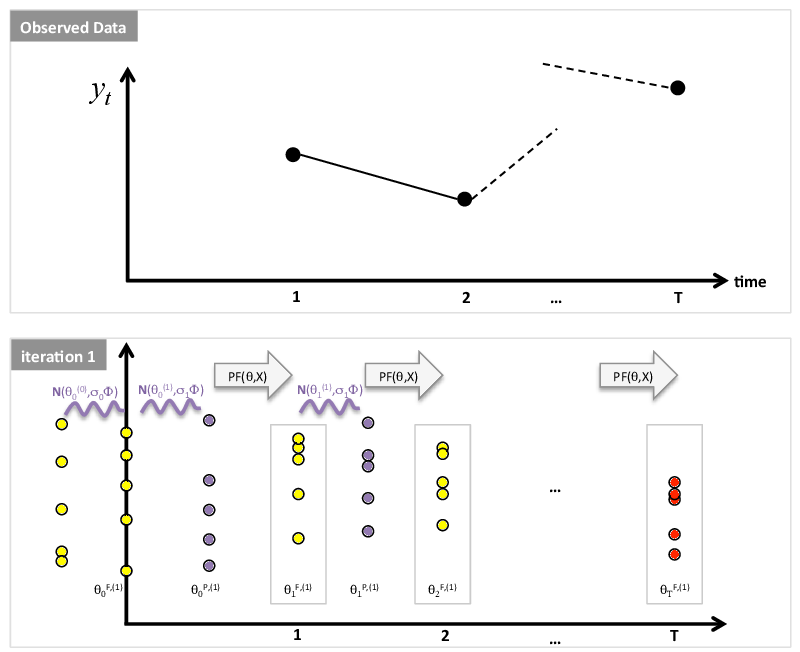

### Iterated filtering, part 2

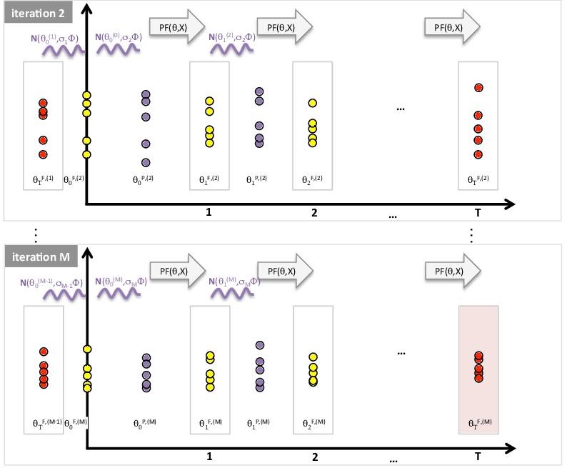

### Iterated filtering: practical considerations

- need to run many, many simulations:  
  usually means writing them in C/C++  
  (`pomp` “Csnippets”, `Rcpp`)
- *particle exhaustion*: how many particles are needed?
- *cooling schedule* needs to be tuned (cf. *simulated annealing*)
- convergence diagnostics
- rough, multimodal surfaces; multiple chains, etc etc
- MLE approach, so need profiling for confidence intervals

### MIF vs PF

From Ionides *et al.* 2015:

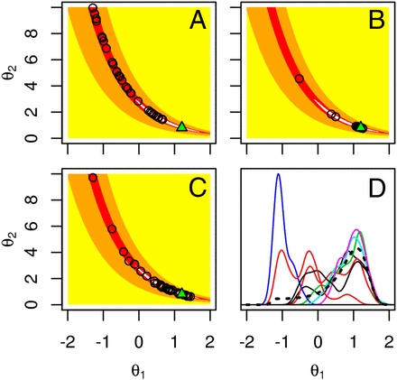